# Trying reading netCDF directly

```r
library(dplyr)
```

Load the `ncdf4` package:

```r
library(ncdf4)
```

Open an example historical output file:

```r
gfdl_hist <- nc_open("~/Downloads/tas_day_GFDL-ESM2G_historical_r1i1p1_19810101-19851231.nc")
print(gfdl_hist)
```

```
File ~/Downloads/tas_day_GFDL-ESM2G_historical_r1i1p1_19810101-19851231.nc (NC_FORMAT_64BIT):

     8 variables (excluding dimension variables):
        double average_DT[time]
            long_name: Length of average period
            units: days
        double average_T1[time]
            long_name: Start time for average period
            units: days since 1861-01-01 00:00:00
        double average_T2[time]
            long_name: End time for average period
            units: days since 1861-01-01 00:00:00
        float tas[lon,lat,time]
            long_name: Near-Surface Air Temperature
            units: K
            valid_range: 100
             valid_range: 400
            cell_methods: time: mean
            coordinates: height
            missing_value: 1.00000002004088e+20
            _FillValue: 1.00000002004088e+20
            standard_name: air_temperature
            original_units: deg_k
            original_name: t_ref
            cell_measures: area: areacella
            associated_files: baseURL: http://cmip-pcmdi.llnl.gov/CMIP5/dataLocation areacella: areacella_fx_GFDL-ESM2G_historical_r0i0p0.nc
        double time_bnds[bnds,time]
            long_name: time axis boundaries
            units: days since 1861-01-01 00:00:00
        double height[]
            units: m
            positive: up
            long_name: height
            standard_name: height
            axis: Z
        double lat_bnds[bnds,lat]
        double lon_bnds[bnds,lon]

     4 dimensions:
        time  Size:1825   *** is unlimited ***
```

[output cut: 37 more lines]

```
        comment: GFDL experiment name = ESM2G-C2_all_historical_HC2. PCMDI experiment name = historical (run1). Initial conditions for this experiment were taken from 1 January of year 1861 of the parent experiment, ESM2G-C2_1700-1860_historical_HC2, which is an unpublished experiment branched from …
        gfdl_experiment_name: ESM2G-C2_all_historical_HC2
        creation_date: 2011-11-19T19:40:22Z
        model_id: GFDL-ESM2G
        branch_time: 58765
        experiment: historical
        forcing: GHG,SD,Oz,LU,Sl,Vl,SS,BC,MD,OC (GHG includes CO2, CH4, N2O, CFC11, CFC12, HCFC22, CFC113)
        frequency: day
        initialization_method: 1
        parent_experiment_id: historicalMisc
        physics_version: 1
        product: output1
        institution: NOAA GFDL(201 Forrestal Rd, Princeton, NJ, 08540)
        history: File was processed by fremetar (GFDL analog of CMOR). TripleID: [exper_id_eDfXZpMNeR,realiz_id_rexsamlwoA,run_id_bSxBCxpGE5]
        parent_experiment_rip: r1i1p1
```

Try getting the location coordinates:

```r
lon <- ncvar_get(gfdl_hist, "lon")
summary(lon)
```

```
   Min. 1st Qu.  Median    Mean 3rd Qu.    Max.
   1.25   90.63  180.00  180.00  269.40  358.80
```

Try getting latitude coordinates:

```r
lat <- ncvar_get(gfdl_hist, "lat")
summary(lat)
```

```
   Min. 1st Qu.  Median    Mean 3rd Qu.    Max.
 -89.49  -45.00    0.00    0.00   45.00   89.49
```

Plot all coordinates:

```r
all_coords <- expand.grid(lon, lat) %>%
        rename(lon = Var1, lat = Var2) %>%
        mutate(lon2 = ifelse(lon > 180, -(360 - lon), lon))
head(all_coords)
```

|  | lon | lat | lon2 |
| --- | --- | --- | --- |
| 1 | 1.25 | -89.49438 | 1.25 |
| 2 | 3.75 | -89.49438 | 3.75 |
| 3 | 6.25 | -89.49438 | 6.25 |
| 4 | 8.75 | -89.49438 | 8.75 |
| 5 | 11.25 | -89.49438 | 11.25 |
| 6 | 13.75 | -89.49438 | 13.75 |

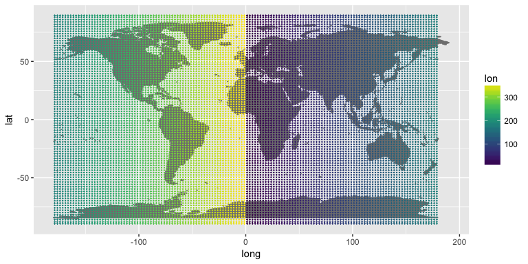

```r
library(ggplot2)
library(ggmap)
library(viridis)
ggplot() +
        borders("world", colour="gray50", fill="gray50") +
        geom_point(data = all_coords, aes(x = lon2, y = lat, color = lon),
                   size = 0.1) +
        scale_color_viridis()
```

Get time from the file:

```r
output_time <- ncvar_get(gfdl_hist, "time")
summary(output_time)
```

```
   Min. 1st Qu.  Median    Mean 3rd Qu.    Max.
  43800   44260   44710   44710   45170   45620
```

Get time units from attributes:

```r
time_units <- ncatt_get(gfdl_hist, "time", "units")
time_units
```

```
$hasatt
[1] TRUE

$value
[1] "days since 1861-01-01 00:00:00"
```

Things seem a little off:

```r
as.Date(43800, origin = "1861-01-01")
```

```
[1] "1980-12-03"
```

```r
as.Date(45620, origin = "1861-01-01")
```

```
[1] "1985-11-27"
```

Pull some of the temperature values:

```r
tas <- ncvar_get(gfdl_hist, "tas")
summary(tas)
```

```
   Min. 1st Qu.  Median    Mean 3rd Qu.    Max.
  193.8   267.3   282.6   277.4   295.1   317.6
```

This is in Kelvin:

```r
ncatt_get(gfdl_hist, "tas", "units")
```

```
$hasatt
[1] TRUE

$value
[1] "K"
```

This has one measure for every latitude-longitude-time combination:

```r
length(lon) * length(lat) * length(output_time) == length(tas)
```

```
[1] TRUE
```

```r
dim(tas)
```

```
[1]  144   90 1825
```

```r
class(tas)
```

```
[1] "array"
```

Here’s an example map of temperature on the first day of this file:

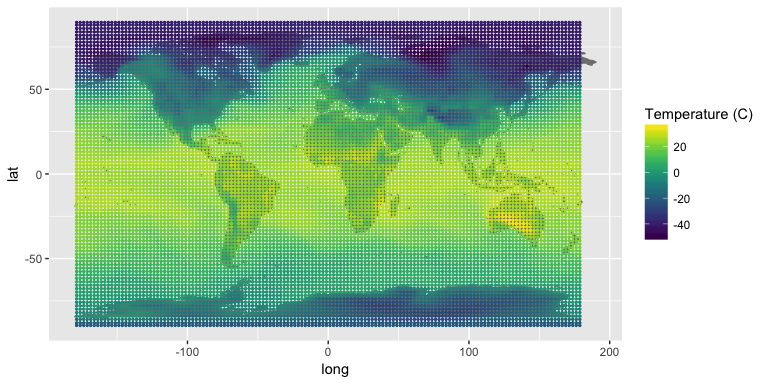

```r
library(weathermetrics)
all_coords %>%
        mutate(tas_day = as.vector(tas[ , , 1]),
               tas_day = convert_temperature(tas_day, "k", "c")) %>%
        ggplot() +
        borders("world", colour="gray50", fill="gray50") +
        geom_point(aes(x = lon2, y = lat, color = tas_day),
                   size = 0.5) +
        scale_color_viridis(name = "Temperature (C)")
```

Here’s a plot for half-way through the first year (summer in the Northern Hemisphere):

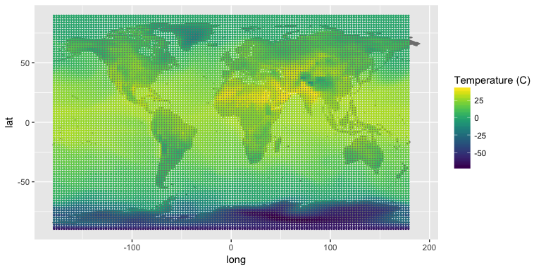

```r
library(weathermetrics)
all_coords %>%
        mutate(tas_day = as.vector(tas[ , , 180]),
               tas_day = convert_temperature(tas_day, "k", "c")) %>%
        ggplot() +
        borders("world", colour="gray50", fill="gray50") +
        geom_point(aes(x = lon2, y = lat, color = tas_day),
                   size = 0.5) +
        scale_color_viridis(name = "Temperature (C)")
```

Get some other metadata from the file:

```r
ncatt_get(gfdl_hist, 0, "title")
```

```
$hasatt
[1] TRUE

$value
[1] "NOAA GFDL GFDL-ESM2G, historical (run 1) experiment output for CMIP5 AR5"
```

```r
ncatt_get(gfdl_hist, 0, "institution")
```

```
$hasatt
[1] TRUE

$value
[1] "NOAA GFDL(201 Forrestal Rd, Princeton, NJ, 08540)"
```

```r
ncatt_get(gfdl_hist, 0, "references")
```

```
$hasatt
[1] TRUE

$value
[1] "The GFDL Data Portal (http://nomads.gfdl.noaa.gov/) provides access to NOAA/GFDL's publicly available model input and output data sets. From this web site one can view and download data sets and documentation, including those related to the GFDL coupled models experiments run for the IPCC's 5th…
```

```r
ncatt_get(gfdl_hist, 0, "history")
```

```
$hasatt
[1] TRUE

$value
[1] "File was processed by fremetar (GFDL analog of CMOR). TripleID: [exper_id_eDfXZpMNeR,realiz_id_rexsamlwoA,run_id_bSxBCxpGE5]"
```

```r
ncatt_get(gfdl_hist, 0, "Conventions")
```

```
$hasatt
[1] TRUE

$value
[1] "CF-1.4"
```

```r
tail(as.character(ts))
```

```
[1] "1985-12-26 12:00:00" "1985-12-27 12:00:00" "1985-12-28 12:00:00" "1985-12-29 12:00:00"
[5] "1985-12-30 12:00:00" "1985-12-31 12:00:00"
```

This seems to work correctly for getting the times.

```r
class(ts)
```

```
[1] "PCICt"
```

```r
gfdl_dates <- as.Date(format(ts), "%Y-%m-%d %H:%M:%s")
summary(gfdl_dates)
```

[output not shown]

[output not shown]

Try some of the functions in `RCMIP5`. It works for processing the file information:

```r
library(RCMIP5)
getFileInfo("~/tmp")
```

| path | filename | variable | domain | model | experiment | ensemble | time | size |
| --- | --- | --- | --- | --- | --- | --- | --- | --- |
| /Users/_gbanders/tmp | tas_day_GFDL-ESM2G_rcp85_r1i1p1_20710101-20751231 | tas | day | GFDL-ESM2G | rcp85 | r1i1p1 | 20710101-20751231 | 92487K |

```r
gfdl <- loadCMIP5("tas", "GFDL-ESM2G", "rcp85", path = "~/tmp/", yearRange = c(2071, 2072))
str(gfdl)
head(gfdl$time)
tail(gfdl$time)
```

[output not shown]

Close the connection:

```r
nc_close(gfdl_hist)
```